# Mapas en acción. Afinando las herramientas

Author

Tomás Bustos

# Mapas en acción: Análisis y visualización espacial con R

## 2. Afinando las herramientas

La idea de este encuentro es profundizar en operaciones complejas para procesamiento de tablas, conocer algunas operaciones espaciales y complejizar las técnicas de visualización.

## 2.1. Pregunta-problema

El objetivo será comparar el desempeño de las cinco fuerzas que compitieron en las elecciones nacionales de 2023 a nivel provincial. En términos globales, ¿cómo fue el resultado? Y sobre cada fuerza en particular, ¿dónde tuvieron mejores y peores resultados?

Cargamos las librerías.

```r
library(tidyverse)
library(sf)
```

## 2.2. Las estrellas de `tidyverse`: grupos y uniones

### Operando sobre grupos

La función `group_by()` nos permite hacer ciertos cálculos por grupos. El esquema lógico es el siguiente.

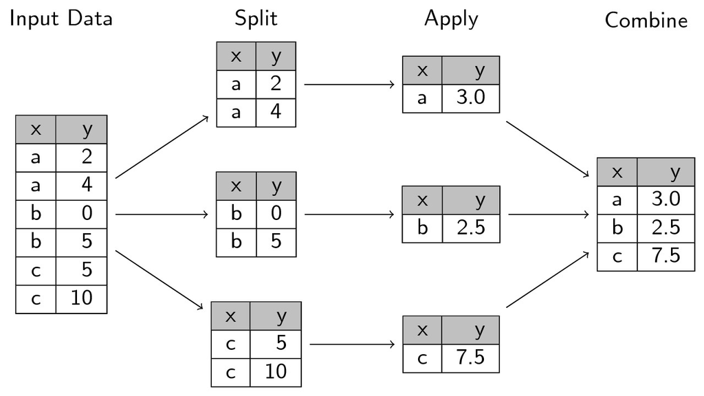

Esquema group_by

Primero cargamos la base de datos que utilizamos el encuentro pasado. Visualicemos el resultado de cada partido en todas las provincias.

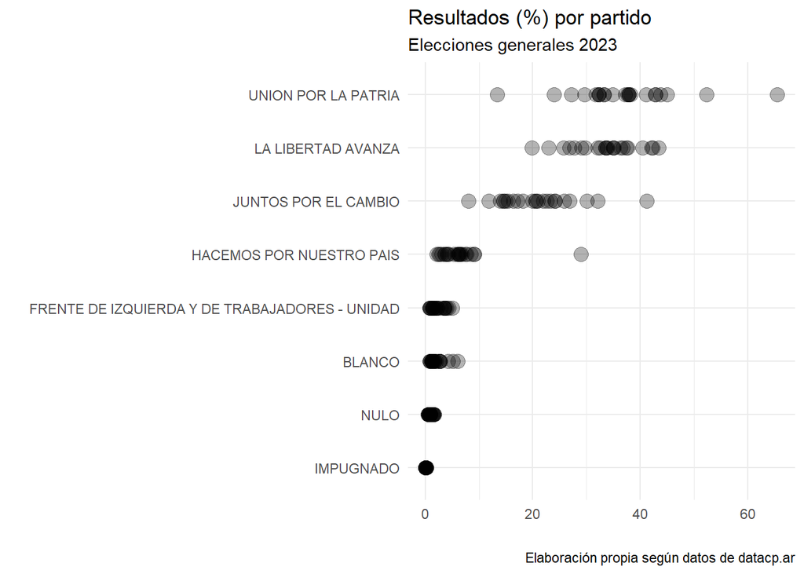

```r
res <- read_csv(params$ruta_csv)

res %>%
  ggplot(aes(y=reorder(Partido,Porcentaje)))+
  geom_point(aes(x=Porcentaje), color="black", size=4, alpha=.3)+
  labs(x="", y="",
    title="Resultados (%) por partido",
       subtitle="Elecciones generales 2023",
       caption="Elaboración propia según datos de datacp.ar")+
  theme_minimal()
```

Es un poco difícil entender los resultados de esta forma. Calculemos el promedio, mínimo y máximo de cada uno de los partidos.

```r
grouped <- res %>%
  group_by(Partido) %>%
  summarise(promedio = round(mean(Porcentaje),1),
            min = round(min(Porcentaje),1),
            max = round(max(Porcentaje),1)) %>%
  arrange(desc(promedio))

grouped
```

```
# A tibble: 8 × 4
  Partido                                        promedio   min   max
  <chr>                                             <dbl> <dbl> <dbl>
1 UNION POR LA PATRIA                                36.8  13.4  65.5
2 LA LIBERTAD AVANZA                                 33.4  19.9  43.4
3 JUNTOS POR EL CAMBIO                               20.8   8.1  41.2
4 HACEMOS POR NUESTRO PAIS                            6.6   2.2  29
5 FRENTE DE IZQUIERDA Y DE TRABAJADORES - UNIDAD      2.4   0.8   5
6 BLANCO                                              2     0.8   6
7 NULO                                                1     0.5   1.7
8 IMPUGNADO                                           0.1   0     0.3
```

También podemos verlo gráficamente.

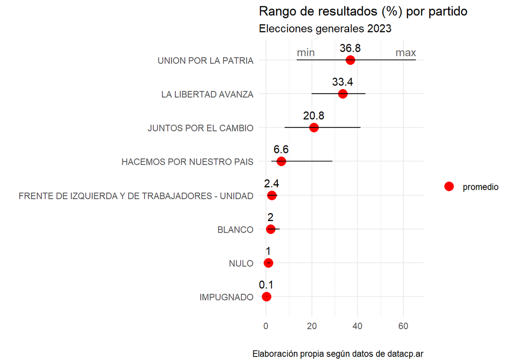

```r
grouped %>%
  ggplot(aes(y=reorder(Partido,promedio)))+
  geom_point(aes(x=promedio, color="promedio"), size=4)+
  geom_segment(aes(x=min, xend=max)) +
  geom_text(aes(x = promedio, label =promedio),
            vjust = -1, color = "black") +
  geom_text(aes(x = min,
                label = ifelse(Partido == first(reorder(Partido, promedio)), "min", "")),
            vjust = -.5, hjust = 0, color = "grey40") +
  geom_text(aes(x = max,
                label = ifelse(Partido == first(reorder(Partido, promedio)), "max", "")),
            vjust = -.5, hjust = 1, color = "grey40") +
  scale_color_manual(values = c("promedio" = "red")) +
  labs(x="", y="", color="",
    title="Rango de resultados (%) por partido",
       subtitle="Elecciones generales 2023",
       caption="Elaboración propia según datos de datacp.ar")+
  theme_minimal()
```

### Uniones

Para cruzar distintas bases de datos podemos usar las funciones `_join()` disponibles en `tidyverse`. Una buena práctica es chequear que las claves funcionen correctamente antes de realizar la unión. Como ya lo hicimos el encuentro anterior vamos a traer la limpieza.

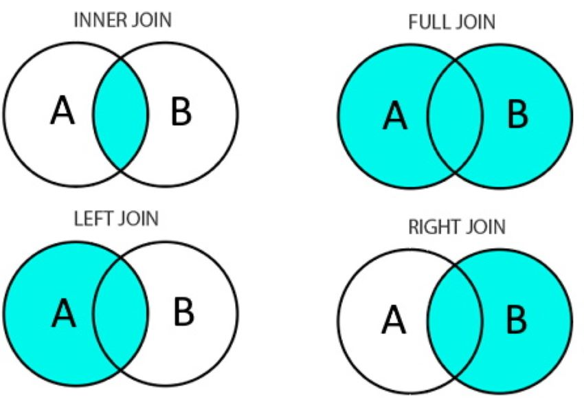

Uniones

```r
geo <- st_read(params$ruta_shp) %>%
  mutate(key = str_to_upper(NAM),
         key = stringi::stri_trans_general(key, "Latin-ASCII"),
         key = str_replace(key, ", ANTARTIDA E ISLAS DEL ATLANTICO SUR", "")) %>%
  select(key, geometry)
```

```r
res %>% distinct(id) %>% arrange(id) %>% as.vector()
```

```
$id
 [1] "BUENOS AIRES"                    "CATAMARCA"
 [3] "CHACO"                           "CHUBUT"
 [5] "CIUDAD AUTONOMA DE BUENOS AIRES" "CORDOBA"
 [7] "CORRIENTES"                      "ENTRE RIOS"
 [9] "FORMOSA"                         "JUJUY"
[11] "LA PAMPA"                        "LA RIOJA"
[13] "MENDOZA"                         "MISIONES"
[15] "NEUQUEN"                         "RIO NEGRO"
[17] "SALTA"                           "SAN JUAN"
[19] "SAN LUIS"                        "SANTA CRUZ"
[21] "SANTA FE"                        "SANTIAGO DEL ESTERO"
[23] "TIERRA DEL FUEGO"                "TUCUMAN"
```

```r
geo %>% st_drop_geometry() %>% distinct(key) %>% arrange(key) %>% as.vector()
```

```
$key
 [1] "BUENOS AIRES"                    "CATAMARCA"
 [3] "CHACO"                           "CHUBUT"
 [5] "CIUDAD AUTONOMA DE BUENOS AIRES" "CORDOBA"
 [7] "CORRIENTES"                      "ENTRE RIOS"
 [9] "FORMOSA"                         "JUJUY"
[11] "LA PAMPA"                        "LA RIOJA"
[13] "MENDOZA"                         "MISIONES"
[15] "NEUQUEN"                         "RIO NEGRO"
[17] "SALTA"                           "SAN JUAN"
[19] "SAN LUIS"                        "SANTA CRUZ"
[21] "SANTA FE"                        "SANTIAGO DEL ESTERO"
[23] "TIERRA DEL FUEGO"                "TUCUMAN"
```

Para utilizar de ejemplo, intentemos realizar las distintas uniones con dos versiones parciales de las tablas que estamos trabajando.

```r
res_short <- res %>%
  mutate(fuente = "resultados") %>%
  select(id, fuente) %>%
  distinct() %>%
  filter(id %in% c("CHUBUT","CORRIENTES", "BUENOS AIRES"))
res_short
```

```
# A tibble: 3 × 2
  id           fuente
  <chr>        <chr>
1 BUENOS AIRES resultados
2 CHUBUT       resultados
3 CORRIENTES   resultados
```

Recortemos también la base de datos geográfica.

```r
geo_short <- geo %>%
  st_drop_geometry() %>%
  mutate(fuente = "geo",
         id = key) %>%
  select(id, fuente) %>%
  distinct() %>%
  filter(id %in% c("SAN JUAN","SAN LUIS", "BUENOS AIRES"))
geo_short
```

```
            id fuente
1     SAN LUIS    geo
2     SAN JUAN    geo
3 BUENOS AIRES    geo
```

En el caso de `inner_join()`, sólo permanecen las claves coincidentes.

```r
res_short %>%
  inner_join(geo_short, by="id")
```

```
# A tibble: 1 × 3
  id           fuente.x   fuente.y
  <chr>        <chr>      <chr>
1 BUENOS AIRES resultados geo
```

En el caso de `left_join()`, sólo permanecen las claves que existen en la primera base.

```r
res_short %>%
  left_join(geo_short, by="id")
```

```
# A tibble: 3 × 3
  id           fuente.x   fuente.y
  <chr>        <chr>      <chr>
1 BUENOS AIRES resultados geo
2 CHUBUT       resultados <NA>
3 CORRIENTES   resultados <NA>
```

En el caso de `right_join()`, sucede lo opuesto.

```r
res_short %>%
  right_join(geo_short, by="id")
```

```
# A tibble: 3 × 3
  id           fuente.x   fuente.y
  <chr>        <chr>      <chr>
1 BUENOS AIRES resultados geo
2 SAN LUIS     <NA>       geo
3 SAN JUAN     <NA>       geo
```

En el caso de `full_join()`, permanecen todas las claves.

```r
res_short %>%
  full_join(geo_short, by="id")
```

```
# A tibble: 5 × 3
  id           fuente.x   fuente.y
  <chr>        <chr>      <chr>
1 BUENOS AIRES resultados geo
2 CHUBUT       resultados <NA>
3 CORRIENTES   resultados <NA>
4 SAN LUIS     <NA>       geo
5 SAN JUAN     <NA>       geo
```

## 2.3. Operaciones espaciales

En el rubro que nos proponemos trabajar los archivos geográficos suelen estar curados y listos para usar. Muchas de las operaciones espaciales que vamos a ver ahora están pensadas para situaciones extraordinarias o para ser creativos al momento de la visualización de la información.

**Buffer**

El buffer genera una zona alrededor de un objeto geométrico a la distancia indicada.

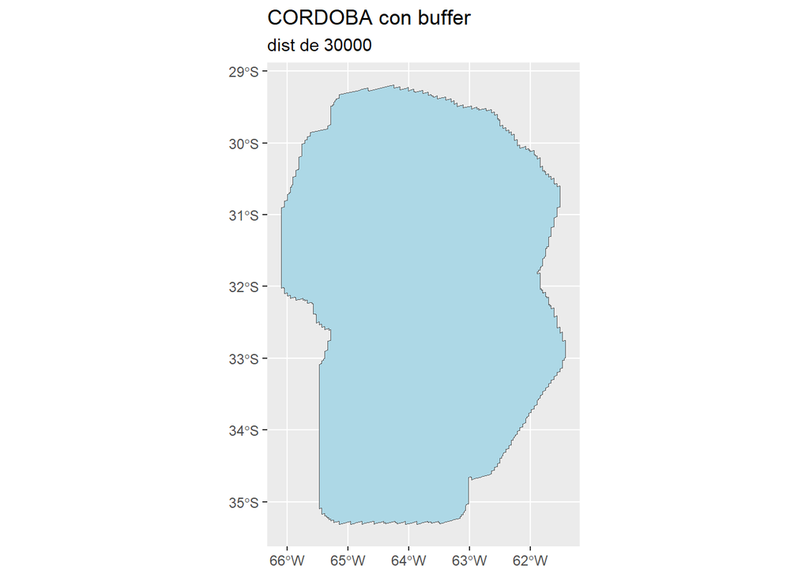

```r
# definiciones
buffer_dist <- 3*10e3
prov <- "CORDOBA"

#calculo
geo %>%
  filter(key==prov) %>%
  st_buffer(dist=buffer_dist) %>%
  ggplot()+
  geom_sf(fill="lightblue")+
  labs(title=paste0(prov," con buffer"),
    subtitle=paste0("dist de ", buffer_dist))
```

**Boundary**

Extrae los bordes de un polígono.

```r
geo %>%
  filter(key == prov) %>%
  st_boundary()
```

```
Simple feature collection with 1 feature and 1 field
Geometry type: MULTILINESTRING
Dimension:     XY
Bounding box:  xmin: -65.77198 ymin: -35.00013 xmax: -61.77089 ymax: -29.50042
Geodetic CRS:  WGS 84
      key                       geometry
1 CORDOBA MULTILINESTRING ((-63.87035...
```

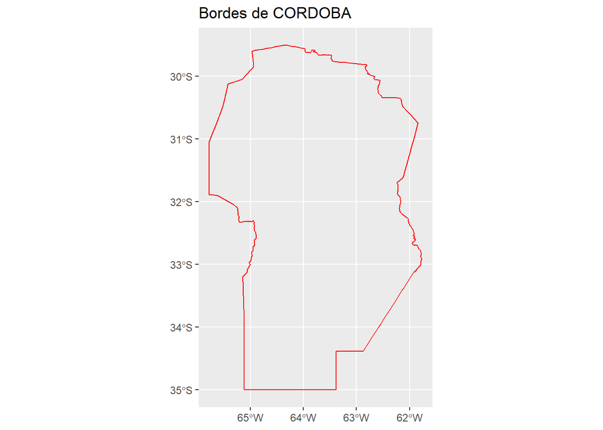

```r
geo %>%
  filter(key==prov) %>%
  st_boundary() %>%
  ggplot()+
  geom_sf(color="red")+
  labs(title=paste0("Bordes de ", prov))
```

**Simplify**

Reduce el número de vértices de un polígono para simplificar su forma, manteniendo la geometría aproximada. Útil para reducir el peso de un archivo y trabajarlo más cómodamente.

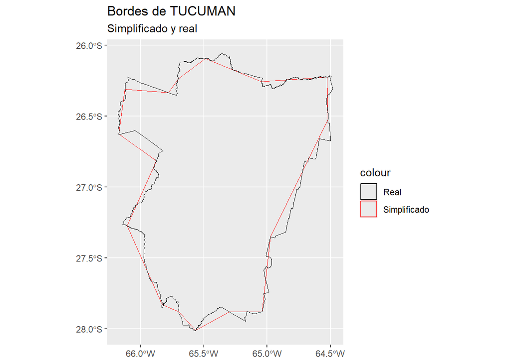

```r
prov <- "TUCUMAN"
geo %>%
  filter(key==prov) %>%
  st_simplify(dTolerance = 10000) %>%
  ggplot()+
  geom_sf(aes(color="Simplificado"), alpha=0, show.legend=TRUE)+
  geom_sf(data=filter(geo, key==prov), aes(color="Real"), alpha=0, show.legend=TRUE)+
  labs(title=paste0("Bordes de ", prov),
       subtitle="Simplificado y real")+
  scale_color_manual(values = c("Simplificado" = "red", "Real" = "black")) # para definir colores
```

**Centroid**

Calcula el centro geométrico de un polígono.

```r
geo_centroid <- geo %>% st_centroid()
geo_centroid %>% head(2)
```

```
Simple feature collection with 2 features and 1 field
Geometry type: POINT
Dimension:     XY
Bounding box:  xmin: -70.10996 ymin: -38.62721 xmax: -58.44591 ymax: -34.61448
Geodetic CRS:  WGS 84
                              key                    geometry
1 CIUDAD AUTONOMA DE BUENOS AIRES POINT (-58.44591 -34.61448)
2                         NEUQUEN POINT (-70.10996 -38.62721)
```

Lo vemos gráficamente.

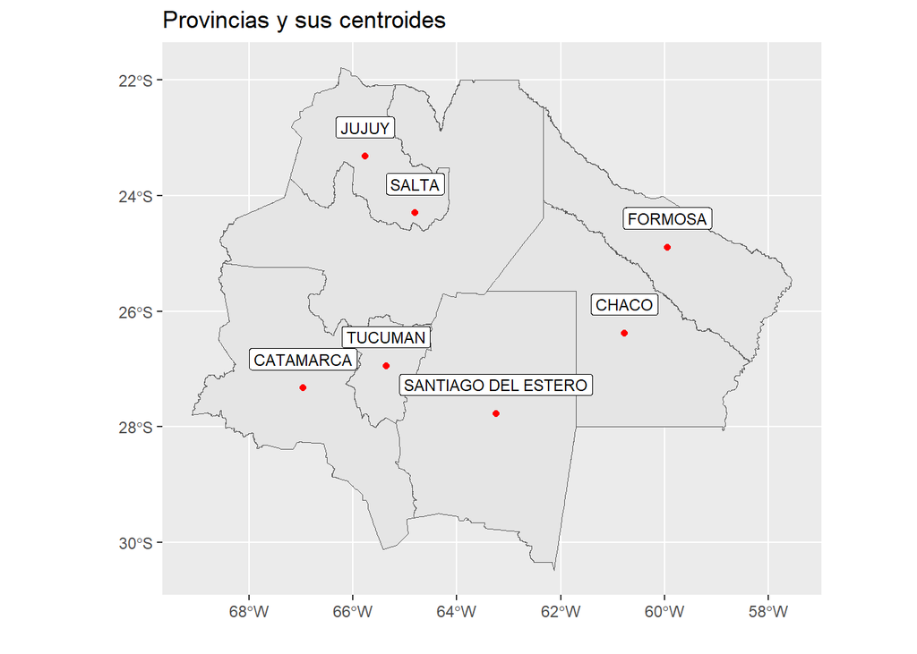

```r
provs <- c("TUCUMAN", "SANTIAGO DEL ESTERO", "SALTA", "JUJUY", "CHACO", "FORMOSA", "CATAMARCA")
geo_centroid_filtrado <- geo_centroid %>% filter(key %in% provs)

geo_centroid_filtrado$X <- geo_centroid_filtrado %>% st_coordinates() %>% as.data.frame() %>% select(X) %>% pull()
geo_centroid_filtrado$Y <- geo_centroid_filtrado %>% st_coordinates() %>% as.data.frame() %>% select(Y) %>% pull()

geo %>%
  filter(key %in% provs) %>%
  ggplot()+
  geom_sf()+
  geom_sf(data=geo_centroid_filtrado, color="red")+
  geom_label(data=geo_centroid_filtrado, aes(label=key, x=X, y=Y+.5), size=3, )+
  labs(x="", y="", title="Provincias y sus centroides")
```

**Área**

Calcula el área de cada polígono. Se devuelve en las unidades del sistema de coordenadas.

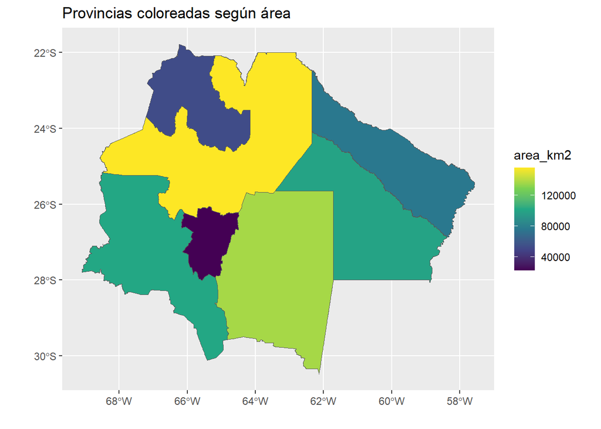

```r
geo <- geo %>%
  mutate(area_m2 = st_area(geometry),
         area_km2 = units::set_units(area_m2, km^2),
         area_km2 = round(as.numeric(area_km2),0))

geo %>%
  filter(key %in% provs) %>%
  ggplot()+
  geom_sf(aes(fill=area_km2))+
  scale_fill_viridis_c()+
  labs(x="", y="", title="Provincias coloreadas según área")
```

¿Y si se incluyen todas las provincias?

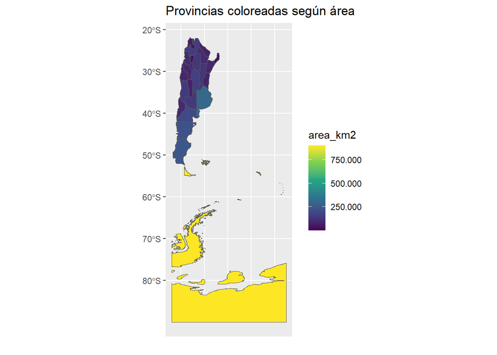

```r
geo %>%
  ggplot()+
  geom_sf(aes(fill=area_km2))+
  scale_fill_viridis_c(labels = scales::label_number(big.mark = ".", decimal.mark = ",")) +
  labs(x="", y="", title="Provincias coloreadas según área")
```

**Recortar**

A veces existen elementos geográficos que no deseamos representar gráficamente. No siempre pueden filtrarse: en este caso, la información geográfica de la Antártida está incluida en el polígono de Tierra del Fuego. En estos casos, se pueden recortar el valor de *geometry* según latitud y longitud. Calculamos nuevamente el área ahora sin incluir a la Antártida en el cálculo.

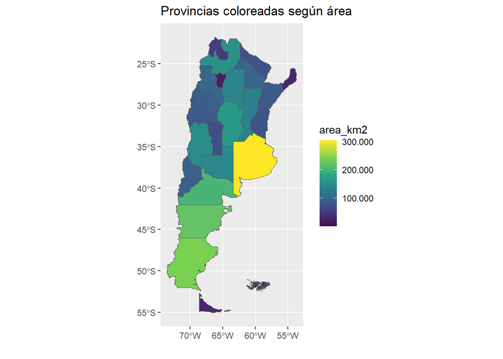

```r
bbox <- st_bbox(c(xmin = -75, ymin = -58, xmax = -52, ymax = -20), crs = st_crs(geo))

geo <- geo %>%
  st_crop(bbox) %>%
  mutate(area_m2 = st_area(geometry),
         area_km2 = units::set_units(area_m2, km^2),
         area_km2 = round(as.numeric(area_km2),0))

geo %>%
  ggplot()+
  geom_sf(aes(fill=area_km2))+
  scale_fill_viridis_c(labels = scales::label_number(big.mark = ".", decimal.mark = ",")) +
  labs(x="", y="", title="Provincias coloreadas según área")
```

### Agregaciones espaciales

La agregación espacial se utiliza para construir objetos geográficos a partir de otros más pequeños. En este caso vamos a ejemplificar construyendo un objeto de **regiones** a partir de nuestro objeto de provincias. Primero construimos la variable de *región* en nuestro dataframe.

```r
geo <- geo %>%
  mutate(region = case_when(
    key %in% c("BUENOS AIRES", "CIUDAD AUTONOMA DE BUENOS AIRES") ~ "BA",
    key %in% c("CORDOBA", "SANTA FE", "ENTRE RIOS", "LA PAMPA") ~ "Centro",
    key %in% c("JUJUY", "SALTA", "TUCUMAN", "CATAMARCA", "LA RIOJA", "SANTIAGO DEL ESTERO") ~ "NOA",
    key %in% c("CHACO", "CORRIENTES", "FORMOSA", "MISIONES") ~ "NEA",
    key %in% c("SAN JUAN", "SAN LUIS", "MENDOZA") ~ "Cuyo",
    key %in% c("NEUQUEN", "RIO NEGRO", "CHUBUT", "SANTA CRUZ", "TIERRA DEL FUEGO") ~ "Patagonia",
    TRUE ~ NA
  ))

geo %>% st_drop_geometry() %>% count(region) %>% arrange(desc(n))
```

```
     region n
1       NOA 6
2 Patagonia 5
3    Centro 4
4       NEA 4
5      Cuyo 3
6        BA 2
```

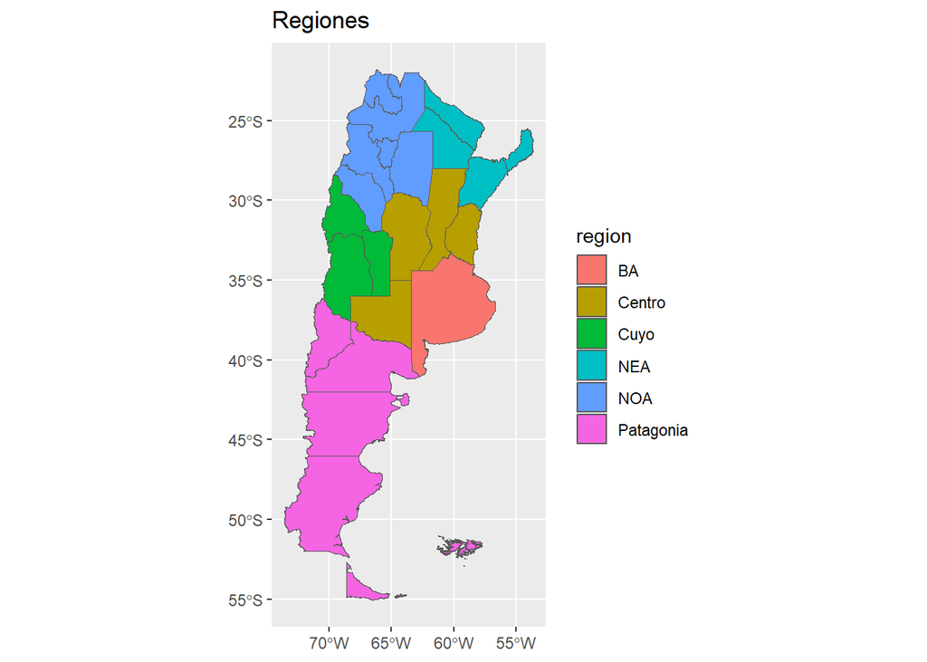

```r
geo %>%
  ggplot()+
  geom_sf(aes(fill=region))+
  labs(title="Regiones")
```

Ahora bien, construyamos el archivo geográfico a nivel región.

```r
region <- geo %>%
  group_by(region) %>%
  summarise(area_km2 = sum(area_km2),
            geometry = st_union(geometry))

region
```

```
Simple feature collection with 6 features and 2 fields
Geometry type: GEOMETRY
Dimension:     XY
Bounding box:  xmin: -73.56659 ymin: -55.06352 xmax: -53.63738 ymax: -21.78086
Geodetic CRS:  WGS 84
# A tibble: 6 × 3
  region    area_km2                                                    geometry
  <chr>        <dbl>                                              <GEOMETRY [°]>
1 BA          305584 POLYGON ((-60.27271 -33.26386, -60.27322 -33.26455, -60.27…
2 Centro      520063 MULTIPOLYGON (((-64.76457 -40.783, -64.76373 -40.7824, -64…
3 Cuyo        312858 POLYGON ((-66.66179 -31.92054, -66.67181 -31.91431, -66.69…
4 NEA         294804 MULTIPOLYGON (((-56.86246 -27.59175, -56.86393 -27.59111, …
5 NOA         562095 POLYGON ((-64.82463 -29.5743, -64.78131 -29.56767, -64.738…
6 Patagonia   796486 MULTIPOLYGON (((-69.41784 -51.088, -69.4201 -51.08735, -69…
```

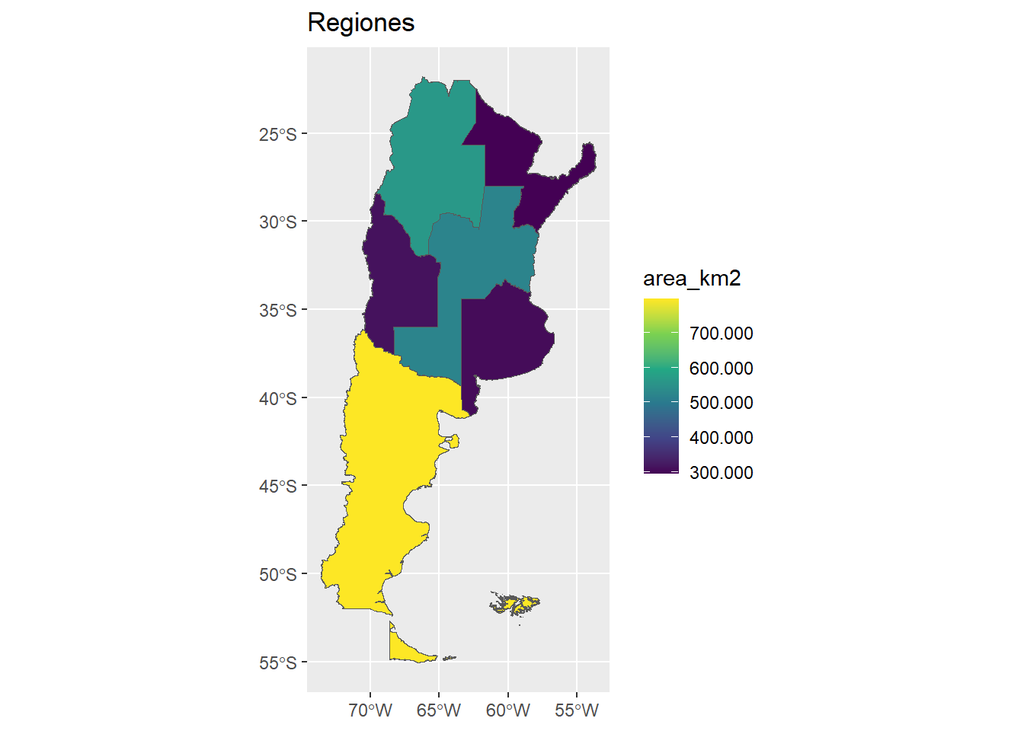

```r
region %>%
  ggplot()+
  geom_sf(aes(fill=area_km2))+
  scale_fill_viridis_c(labels = scales::label_number(big.mark = ".", decimal.mark = ","))+
  labs(title="Regiones")
```

Se podría también construir a nivel país. En ese caso, nuestro objeto tendría una sola fila.

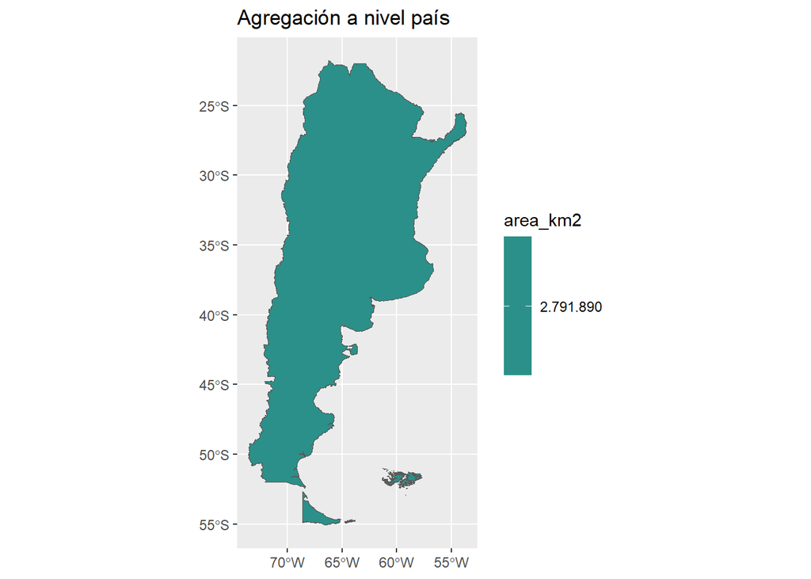

```r
geo %>%
  mutate(pais="ARG") %>%
  group_by(pais) %>%
  summarise(area_km2 = sum(area_km2),
            geometry = st_union(geometry)) %>%
  ggplot()+
  geom_sf(aes(fill=area_km2))+
  scale_fill_viridis_c(labels = scales::label_number(big.mark = ".", decimal.mark = ","))+
  labs(title="Agregación a nivel país")
```

## 🧪 Práctica corta (15 minutos)

Elegir y resolver alguna de las siguientes consignas.

- Sumar la mediana al gráfico de promedio por provincia. Usar otro color para distinguir las dos medidas de centralidad.
- Tomar una de las regiones ya creadas y graficar el área en los polígonos. Sumar centroides y etiquetas.
- Graficar el área de para todas las provincias utilizando bordes simplificados. Jugar con el valor de simplificación para que se note la operación.

## 2.4. Visualizando resultados electorales

### Secuenciales

Lo primero es unir los reusltados electorales con la información geográfica. Utilizaremos el formato *long* porque es más amable para construir algunos gráficos con `ggplot()`.

```r
geo <- geo %>%
  select(key, region, geometry)

df <- res %>%
  mutate(key = id,
         Porcentaje = as.numeric(Porcentaje)) %>%
  left_join(geo, by="key") %>%
  st_as_sf()

df %>%
  head()
```

```
Simple feature collection with 6 features and 10 fields
Geometry type: MULTIPOLYGON
Dimension:     XY
Bounding box:  xmin: -72.18826 ymin: -45.99979 xmax: -56.66499 ymax: -24.0844
Geodetic CRS:  WGS 84
# A tibble: 6 × 11
  id       Elecciones Partido Porcentaje  Votos Participacion Electores Votantes
  <chr>    <chr>      <chr>        <dbl>  <dbl>         <dbl>     <dbl>    <dbl>
1 BUENOS … GENERALES… BLANCO        2.64 269648          77.7  13124435 10199399
2 CATAMAR… GENERALES… BLANCO        5.16  12804          72.8    340606   247986
3 CHACO    GENERALES… BLANCO        1.1    7960          72.4   1000094   724566
4 CHUBUT   GENERALES… BLANCO        1.27   4502          74.5    474701   353825
5 CIUDAD … GENERALES… BLANCO        1.69  32311          75.6   2526676  1911431
6 CORDOBA  GENERALES… BLANCO        0.77  17852          76.2   3060943  2332248
# ℹ 3 more variables: key <chr>, region <chr>, geometry <MULTIPOLYGON [°]>
```

Ante todo, volvamos adonde dejamos el último encuentro. Utilizamos una paleta secuencial que utiliza un mismo color en distintas intensidades.

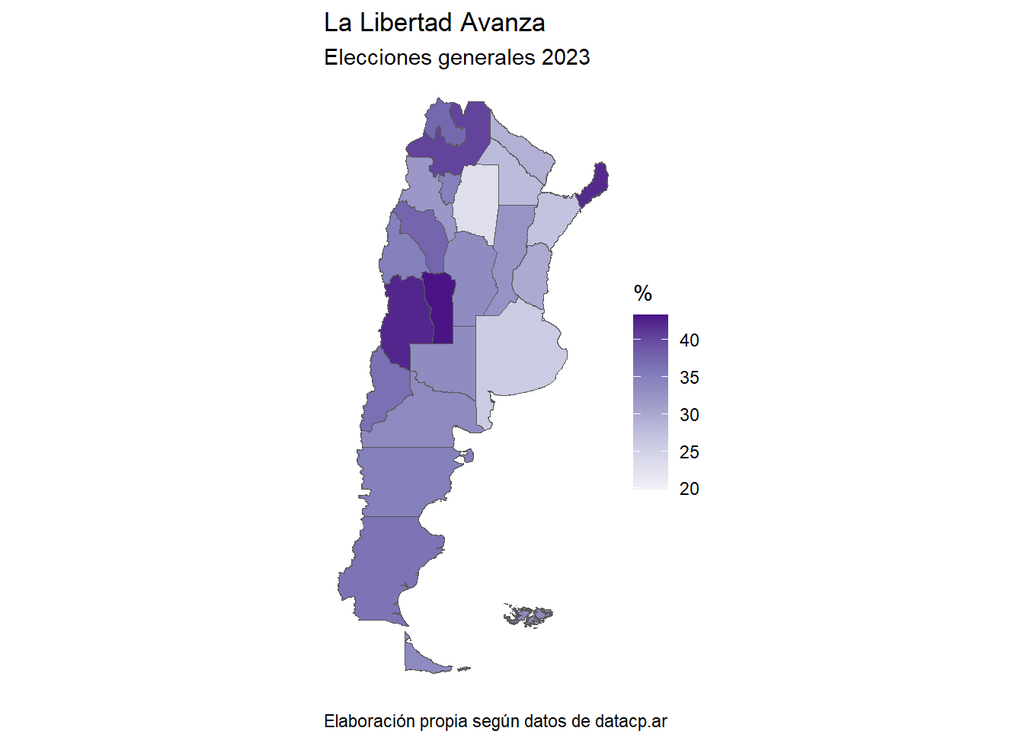

```r
df %>%
  filter(Partido == "LA LIBERTAD AVANZA") %>%
  ggplot()+
  geom_sf(aes(fill=Porcentaje)) +
  scale_fill_distiller(palette = "Purples", direction = 1) +
  labs(x="", y="", fill="%",
       title="La Libertad Avanza",
       subtitle="Elecciones generales 2023",
       caption="Elaboración propia según datos de datacp.ar")+
  theme_void()+
  theme(plot.caption = element_text(hjust = 0))
```

Hay algunos elementos estéticos que tiene sentido modificar. Por ejemplo, marcar mejor los bordes (con el argumento `color` dentro de `geom_sf()`), agregar etiquetas con `geom_sf_label()` o formatear los números de la leyenda con `scales`.

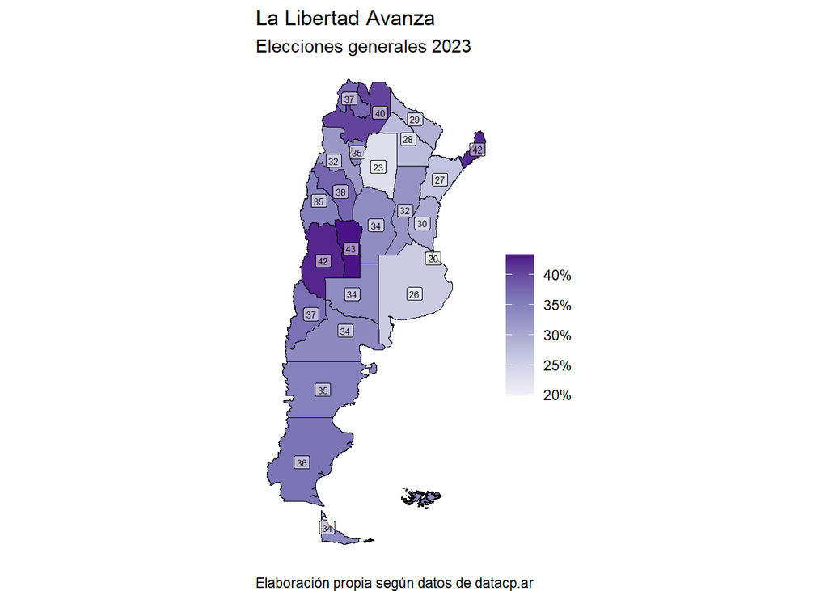

```r
df %>%
  filter(Partido == "LA LIBERTAD AVANZA") %>%
  mutate(label = round(Porcentaje)) %>%
  ggplot()+
  geom_sf(aes(fill=Porcentaje), color="black") +
  geom_sf_label(aes(label=label), size = 2, fill = "white", color = "black", alpha=.5)+
  scale_fill_distiller(palette = "Purples", direction = 1, labels = scales::label_number(suffix = "%")) +
  labs(x="", y="", fill="",
       title="La Libertad Avanza",
       subtitle="Elecciones generales 2023",
       caption="Elaboración propia según datos de datacp.ar")+
  theme_void()+
  theme(plot.caption = element_text(hjust = 0))
```

A veces las escalas continuas son difíciles para interpretar los resultados. Se puede recurrir a generar grupos con los valores analizados. Por defecto, `scale_fill_fermenter()` utiliza rangos de intervalos de igual tamaño.

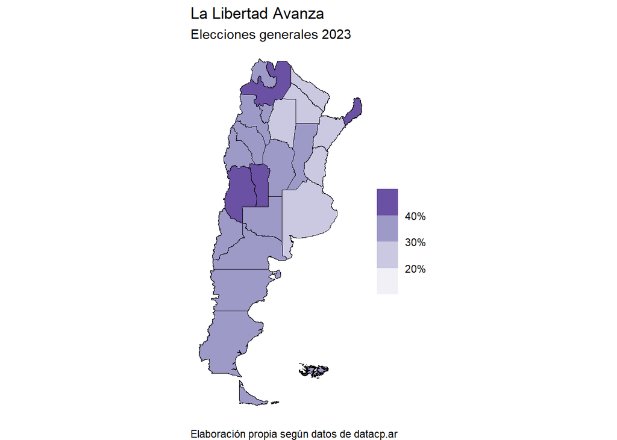

```r
df %>%
  filter(Partido == "LA LIBERTAD AVANZA") %>%
  mutate(label = round(Porcentaje)) %>%
  ggplot()+
  geom_sf(aes(fill=Porcentaje), color="black") +
  scale_fill_fermenter(palette = "Purples", direction = 1,
                       n.breaks=3,
                       labels = scales::label_number(suffix = "%")) +
  labs(x="", y="", fill="",
       title="La Libertad Avanza",
       subtitle="Elecciones generales 2023",
       caption="Elaboración propia según datos de datacp.ar")+
  theme_void()+
  theme(plot.caption = element_text(hjust = 0))
```

Podría querer definir los puntos de corte. Por ejemplo, en el total nacional.

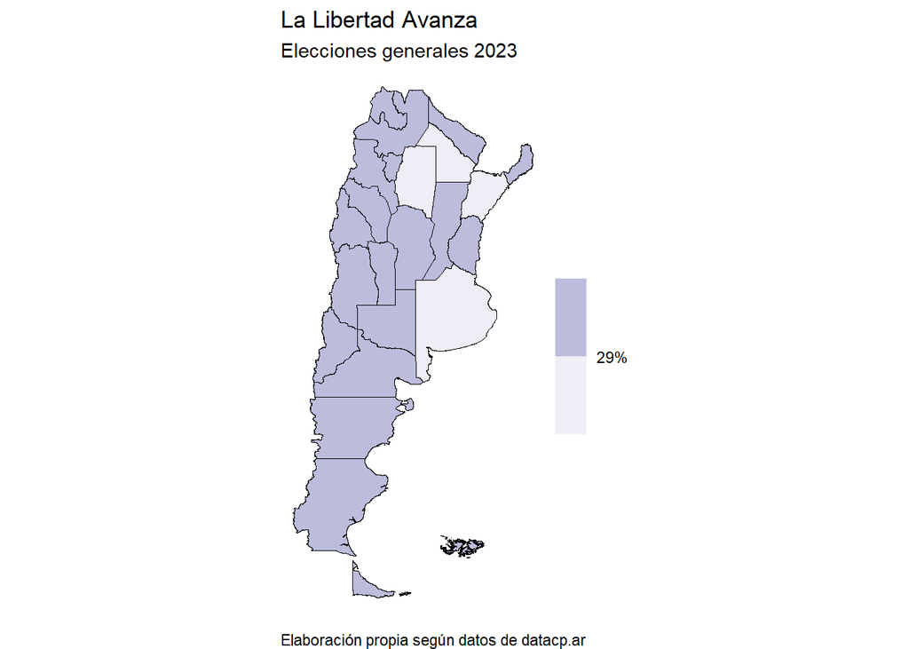

```r
df %>%
  filter(Partido == "LA LIBERTAD AVANZA") %>%
  mutate(label = round(Porcentaje)) %>%
  ggplot()+
  geom_sf(aes(fill=Porcentaje), color="black") +
  scale_fill_fermenter(palette = "Purples", direction = 1,
                       breaks = c(0, 29, 100),
                       labels = scales::label_number(suffix = "%")) +
  labs(x="", y="", fill="",
       title="La Libertad Avanza",
       subtitle="Elecciones generales 2023",
       caption="Elaboración propia según datos de datacp.ar")+
  theme_void()+
  theme(plot.caption = element_text(hjust = 0))
```

Hay diversas formas de generar grupos a partir de una serie continua de valores.

**Intervalos iguales**

Es útil cuando te interesa más el valor que la cantidad de unidades que están incluidas en el rango.

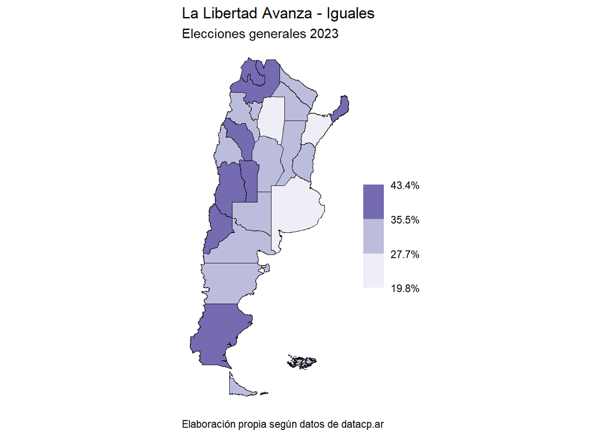

```r
k <- 3

serie <- df %>%
  filter(Partido == "LA LIBERTAD AVANZA") %>%
  pull(Porcentaje)

breaks <- classInt::classIntervals(serie, n=k, style="equal")$brks

df %>%
  filter(Partido == "LA LIBERTAD AVANZA") %>%
  mutate(label = round(Porcentaje)) %>%
  ggplot()+
  geom_sf(aes(fill=Porcentaje), color="black") +
  scale_fill_fermenter(palette = "Purples", direction = 1,
                       breaks = breaks,
                       labels = scales::label_number(suffix = "%")) +
  labs(x="", y="", fill="",
       title="La Libertad Avanza - Iguales",
       subtitle="Elecciones generales 2023",
       caption="Elaboración propia según datos de datacp.ar")+
  theme_void()+
  theme(plot.caption = element_text(hjust = 0))
```

**Cuantiles**

Es útil cuando se precisa que cada grupo tenga la misma cantidad de observaciones.

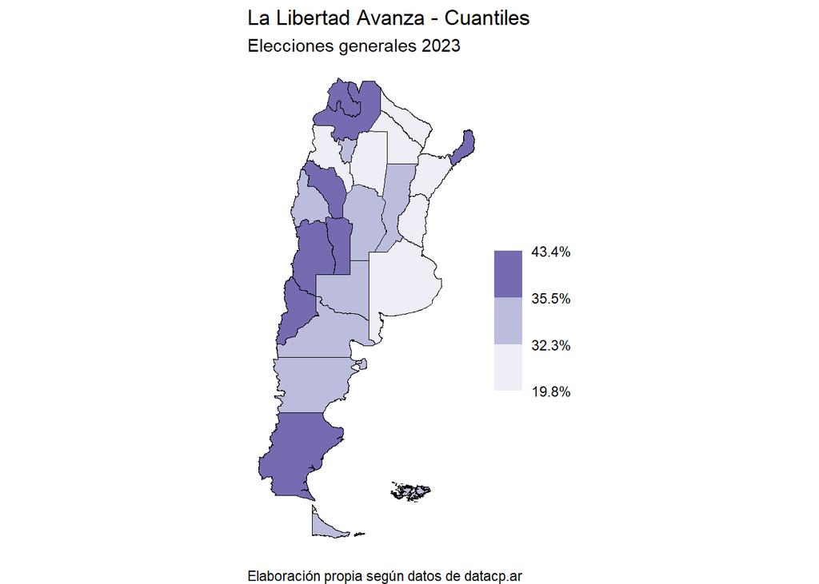

```r
breaks <- classInt::classIntervals(serie, n=k, style="quantile")$brks

df %>%
  filter(Partido == "LA LIBERTAD AVANZA") %>%
  mutate(label = round(Porcentaje)) %>%
  ggplot()+
  geom_sf(aes(fill=Porcentaje), color="black") +
  scale_fill_fermenter(palette = "Purples", direction = 1,
                       breaks = breaks,
                       labels = scales::label_number(suffix = "%")) +
  labs(x="", y="", fill="",
       title="La Libertad Avanza - Cuantiles",
       subtitle="Elecciones generales 2023",
       caption="Elaboración propia según datos de datacp.ar")+
  theme_void()+
  theme(plot.caption = element_text(hjust = 0))
```

**Cortes naturales**

Usualmente se utiliza el método *Jenks*. Los grupos que se forman buscan maximizar sus diferencias; en otras palabras, se colocan los límites donde hay mayores diferencias entre los valores.

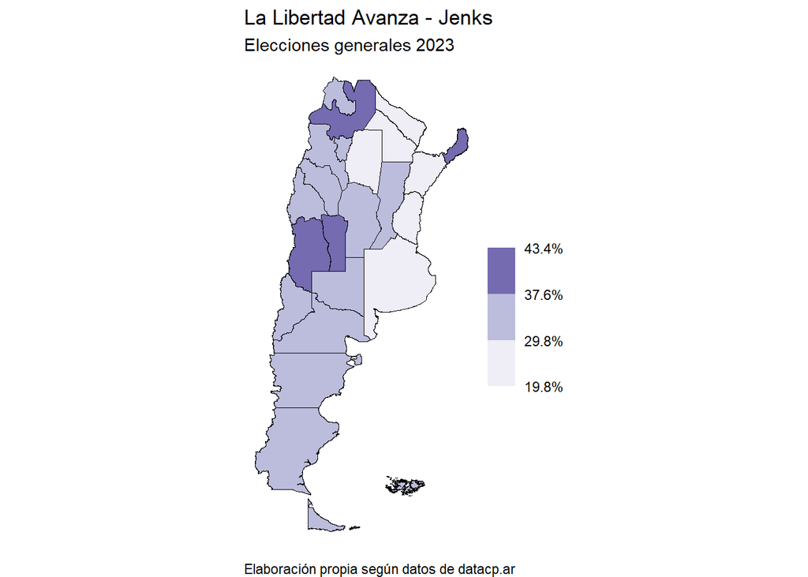

```r
breaks <- classInt::classIntervals(serie, n=k, style="jenks")$brks

df %>%
  filter(Partido == "LA LIBERTAD AVANZA") %>%
  mutate(label = round(Porcentaje)) %>%
  ggplot()+
  geom_sf(aes(fill=Porcentaje), color="black") +
  scale_fill_fermenter(palette = "Purples", direction = 1,
                       breaks = breaks,
                       labels = scales::label_number(suffix = "%")) +
  labs(x="", y="", fill="",
       title="La Libertad Avanza - Jenks",
       subtitle="Elecciones generales 2023",
       caption="Elaboración propia según datos de datacp.ar")+
  theme_void()+
  theme(plot.caption = element_text(hjust = 0))
```

**Comparación**

Comparación entre métodos de clasificación.

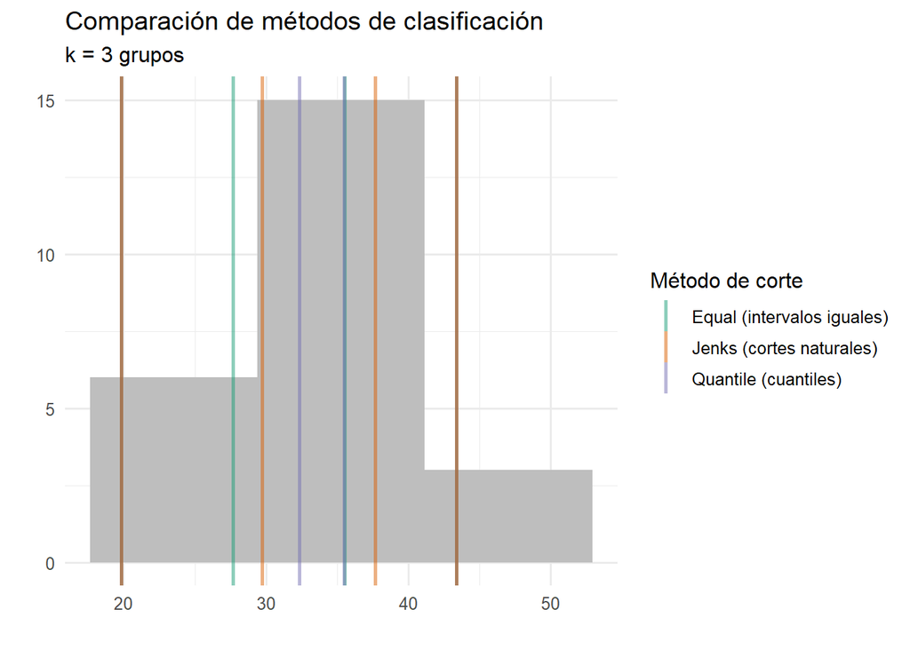

```r
breaks_df <- tibble(
  metodo = c("Equal (intervalos iguales)",
             "Quantile (cuantiles)",
             "Jenks (cortes naturales)"),
  breaks = list(
    classInt::classIntervals(serie, n = k, style = "equal")$brks,
    classInt::classIntervals(serie, n = k, style = "quantile")$brks,
    classInt::classIntervals(serie, n = k, style = "jenks")$brks
  )
) %>%
  unnest_longer(breaks)

ggplot(data.frame(Porcentaje = serie), aes(x = Porcentaje)) +
  geom_histogram(bins = 3, fill="gray") +
  geom_vline(
    data = breaks_df,
    aes(xintercept = breaks, color = metodo),
    linewidth = 0.9,
    alpha=.5
  ) +
  scale_color_manual(values = c("#1b9e77", "#d95f02", "#7570b3")) +
  labs(
    title = "Comparación de métodos de clasificación",
    subtitle = paste("k =", k, "grupos"),
    x = "",
    y = "",
    color = "Método de corte"
  ) +
  theme_minimal(base_size = 12)
```

### Divergentes

Cuando la información que estamos mostrando tiene un rango que incluye números negativos y positivos, puede ser más adecuado utilizar una paleta divergente, compuesta por dos colores y un centro neutro (blanco, gris, negro). Carguemos los resultados de las últimas elecciones para utilizarla.

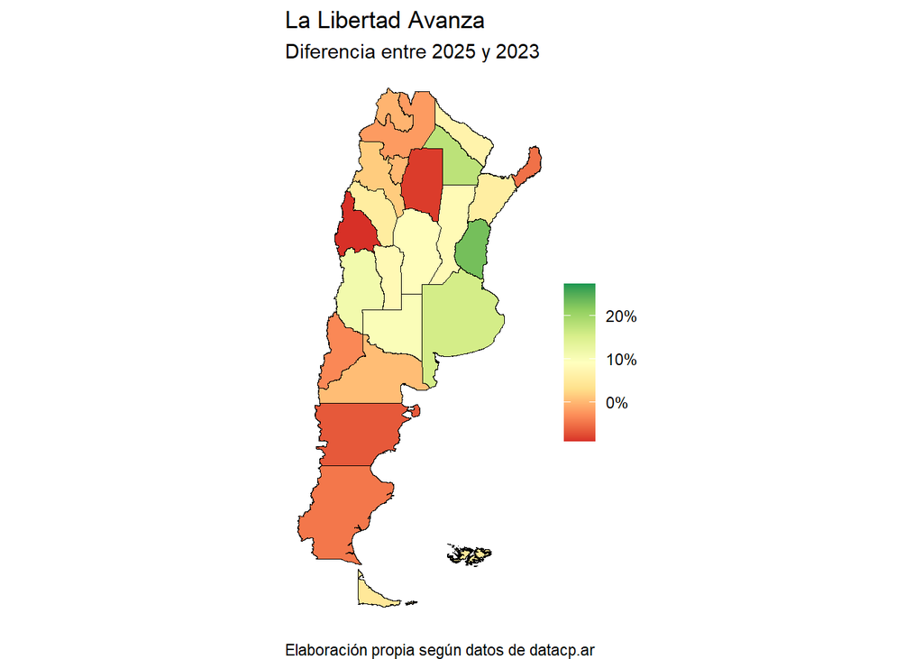

```r
g2025 <- readxl::read_excel(params$ruta_g25) %>%
  rename(porcentaje_2025 = Porcentaje) %>%
  select(-Elecciones)

dif <- df %>%
  filter(Partido == "LA LIBERTAD AVANZA") %>%
  left_join(g2025, by=c("key","Partido")) %>%
  mutate(dif = porcentaje_2025 - Porcentaje)

dif %>%
  ggplot()+
  geom_sf(aes(fill=dif), color="black") +
  scale_fill_distiller(palette = "RdYlGn", direction = 1,
                       labels = scales::label_number(suffix = "%"),
                       ) +
  labs(x="", y="", fill="",
       title="La Libertad Avanza",
       subtitle="Diferencia entre 2025 y 2023",
       caption="Elaboración propia según datos de datacp.ar")+
  theme_void()+
  theme(plot.caption = element_text(hjust = 0))
```

Es más adecuado que el color neutro esté cerca del valor neutro. En este caso, cero y controlar la equivalencia de en las intensidades entre los dos colores.

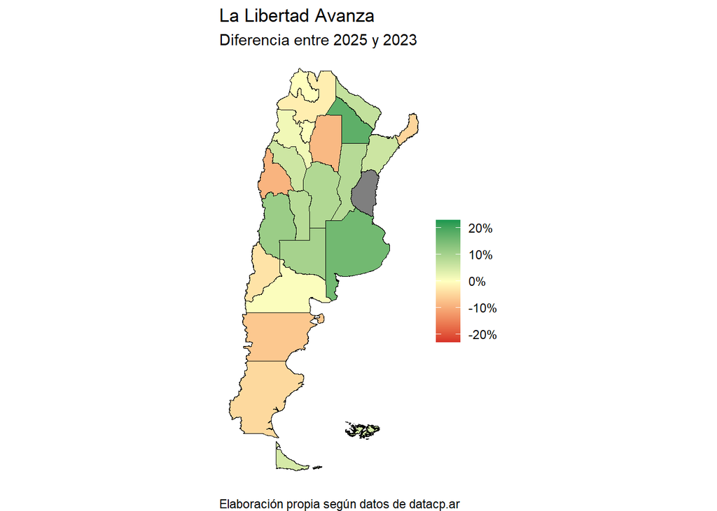

```r
dif %>%
  ggplot()+
  geom_sf(aes(fill=dif), color="black") +
  scale_fill_gradient2(low = "#D73027", mid = "#FFFFBF", high = "#1A9850",
                       midpoint=0, limits=c(-23, 23),
                       labels = scales::label_number(suffix = "%")
                       ) +
  labs(x="", y="", fill="",
       title="La Libertad Avanza",
       subtitle="Diferencia entre 2025 y 2023",
       caption="Elaboración propia según datos de datacp.ar")+
  theme_void()+
  theme(plot.caption = element_text(hjust = 0))
```

### Cualitativas

El último tipo de paletas se utiliza cuando el valor que presentado es categórico. Podríamos intentar con ganador por provincia.

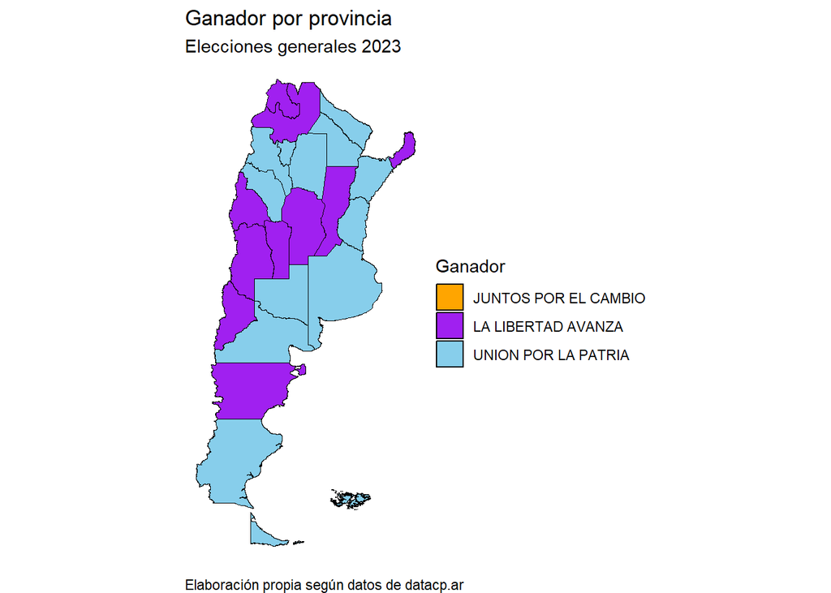

```r
colores <- c( "UNION POR LA PATRIA" = "skyblue",
              "LA LIBERTAD AVANZA" = "purple",
              "JUNTOS POR EL CAMBIO" = "orange",
              "HACEMOS POR NUESTRO PAIS" = "green",
              "FRENTE DE IZQUIERDA Y DE TRABAJADORES - UNIDAD" = "red" )

df %>%
  group_by(key) %>%
  slice_max(order_by=Porcentaje, n=1) %>%
  ggplot()+
  geom_sf(aes(fill=Partido), color="black")+
  scale_fill_manual(values=colores, name="Ganador")+
  labs(x="", y="", fill="",
       title="Ganador por provincia",
       subtitle="Elecciones generales 2023",
       caption="Elaboración propia según datos de datacp.ar")+
  theme_void()+
  theme(plot.caption = element_text(hjust = 0))
```

## 🧩 Para seguir practicando

- Graficar la diferencia del peronismo entre 2025 y 2023.
- Graficar ganador de las elecciones 2023 pero a nivel región.
- Graficar la diferencia de La Libertad Avanza entre 2025 y 2023 utilizando una paleta divergente pero con sus valores clasificados en 3 o 5 grupos.

## 2.5 Bonus track

Si quisiera replicar este mismo mapa para distintos partidos sin repetir cinco veces el mismo código, una alternativa opción es la siguiente.

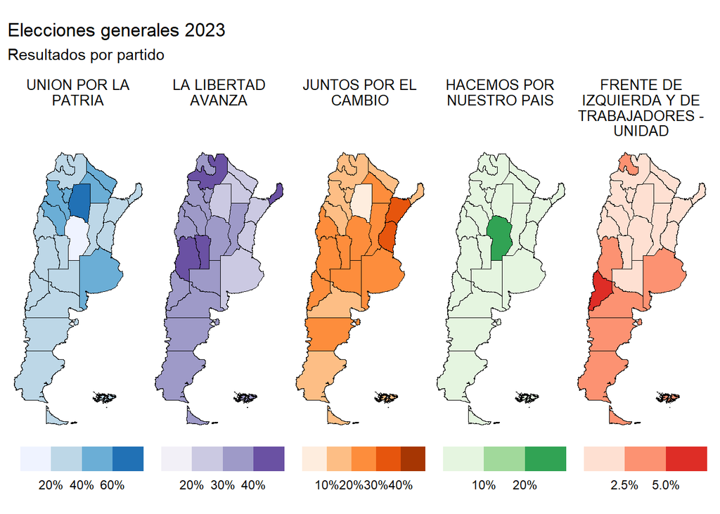

```r
paletas <- c( "UNION POR LA PATRIA" = "Blues",
              "LA LIBERTAD AVANZA" = "Purples",
              "JUNTOS POR EL CAMBIO" = "Oranges",
              "HACEMOS POR NUESTRO PAIS" = "Greens",
              "FRENTE DE IZQUIERDA Y DE TRABAJADORES - UNIDAD" = "Reds")

funcion_plot <- function(p) {
  df %>%
    filter(Partido == p) %>%
    ggplot() +
    geom_sf(aes(fill = Porcentaje), color = "black", size = 0.1) +
    scale_fill_fermenter(palette = paletas[p], direction = 1, n.breaks=3,
                         labels = scales::label_number(suffix = "%")) +
    labs(title = str_wrap(p, 15), fill="") +
    theme_void() +
    theme(plot.title = element_text(hjust = 0.5, size=10),
          legend.position = "bottom",
          legend.direction = "horizontal")
}

plots <- lapply(names(paletas), funcion_plot)

# Combinar los plots
patchwork::wrap_plots(plots, ncol = 5) +
  patchwork::plot_annotation(title="Elecciones generales 2023",
                             subtitle="Resultados por partido")
```